# COMPARAISON DE REGIMES ALIMENTAIRES

Serigne Fallou MBacke NGOM

2024-02-15

## PREPARATION DES DONNEES:

```r
# Création des données
donnees <- data.frame(
  Regime = rep(c("Regime1", "Regime2", "Regime3", "Regime4"), each = 3),
  C = c(3.72, 3.40, 3.12, 4.21, 3.67, 3.82, 3.10, 3.37, 3.78, 4.13, 3.51, 3.39),
  PB = c(16.82, 17.46, 17.20, 18.75, 18.46, 15.76, 17.13, 19.21, 16.79, 18.23, 15.30, 18.04),
  MG = c(9.47, 10.46, 8.80, 6.36, 7.37, 11.30, 10.56, 10.63, 8.71, 10.69, 9.71, 9.95)
)

# Afficher les données
print(donnees)
```

```
##     Regime    C    PB    MG
## 1  Regime1 3.72 16.82  9.47
## 2  Regime1 3.40 17.46 10.46
## 3  Regime1 3.12 17.20  8.80
## 4  Regime2 4.21 18.75  6.36
## 5  Regime2 3.67 18.46  7.37
## 6  Regime2 3.82 15.76 11.30
## 7  Regime3 3.10 17.13 10.56
## 8  Regime3 3.37 19.21 10.63
## 9  Regime3 3.78 16.79  8.71
## 10 Regime4 4.13 18.23 10.69
## 11 Regime4 3.51 15.30  9.71
## 12 Regime4 3.39 18.04  9.95
```

## VISUALISATION DES DONNEES:

### Boxplot teneur en C pour les regimes

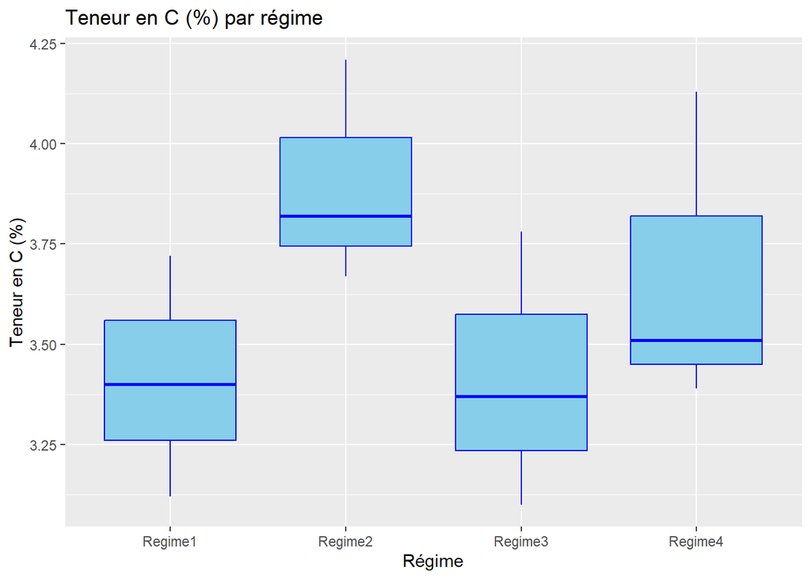

```r
# Charger la bibliothèque ggplot2
library(ggplot2)

ggplot(donnees, aes(x = Regime, y = C)) +
  geom_boxplot(fill = "skyblue", color = "blue") +
  labs(title = "Teneur en C (%) par régime", x = "Régime", y = "Teneur en C (%)")
```

### Boxplot teneur en PB pour les regimes

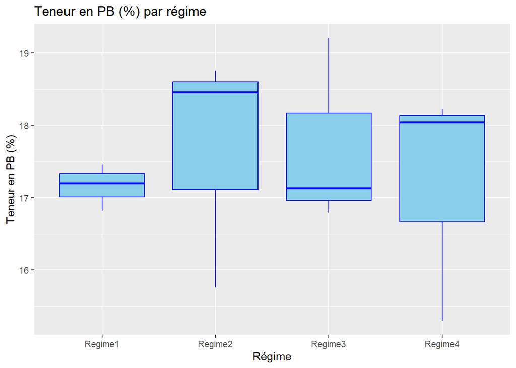

```r
# Charger la bibliothèque ggplot2
library(ggplot2)

ggplot(donnees, aes(x = Regime, y = PB)) +
  geom_boxplot(fill = "skyblue", color = "blue") +
  labs(title = "Teneur en PB (%) par régime", x = "Régime", y = "Teneur en PB (%)")
```

### Boxplot teneur en MG pour les regimes

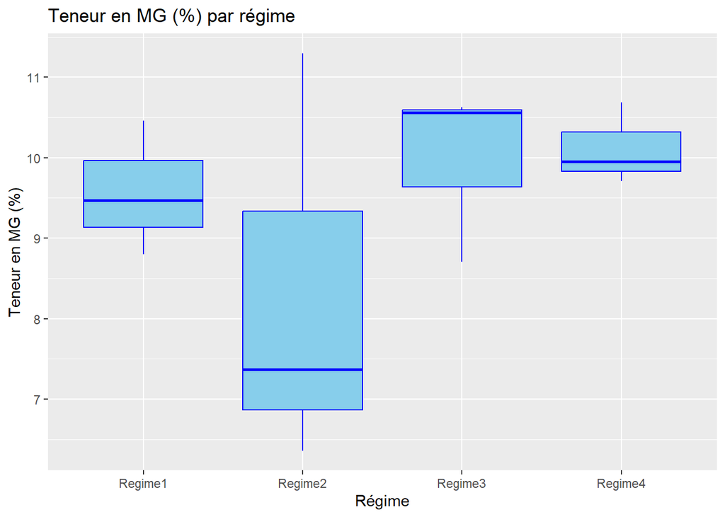

```r
# Charger la bibliothèque ggplot2
library(ggplot2)

ggplot(donnees, aes(x = Regime, y = MG)) +
  geom_boxplot(fill = "skyblue", color = "blue") +
  labs(title = "Teneur en MG (%) par régime", x = "Régime", y = "Teneur en MG (%)")
```

## TESTS STATISTIQUES:

### Test d’ANOVA pour la teneur en C

```r
anova_C <- aov(C ~ Regime, data = donnees)
summary(anova_C)
```

```
##             Df Sum Sq Mean Sq F value Pr(>F)
## Regime       3 0.4930  0.1643   1.484  0.291
## Residuals    8 0.8856  0.1107
```

Les résultats de l’ANOVA pour la teneur en C montrent un F-value de 1.484 avec une p-value de 0.291. Cela indique que le modèle n’est pas statistiquement significatif, car la p-value est supérieure à un seuil alpha typique de 0.05. Par conséquent, **il n’y a pas de différences significatives dans la teneur en C (%) entre les différents régimes**.

### Test d’ANOVA pour la teneur en PB

```r
anova_PB <- aov(PB ~ Regime, data = donnees)
summary(anova_PB)
```

```
##             Df Sum Sq Mean Sq F value Pr(>F)
## Regime       3  0.781  0.2603   0.144  0.931
## Residuals    8 14.454  1.8068
```

Les résultats de l’ANOVA pour la teneur en PB montrent un F-value de 0.144 avec une p-value de 0.931. Cela indique que le modèle n’est pas statistiquement significatif, car la p-value est bien supérieure au seuil alpha typique de 0.05. Par conséquent, il n’y a pas suffisamment de preuves pour rejeter l’hypothèse nulle, ce qui signifie qu’**il n’y a pas de différences significatives dans la teneur en PB entre les différents régimes.**

### Test d’ANOVA pour la teneur en MG

```r
anova_MG <- aov(MG ~ Regime, data = donnees)
summary(anova_MG)
```

```
##             Df Sum Sq Mean Sq F value Pr(>F)
## Regime       3  5.825   1.942   0.867  0.497
## Residuals    8 17.911   2.239
```

F-value de 0.867 avec une p-value de 0.497 (supérieure au seuil alpha typique de 0.05). Par conséquent, **il n’y a pas de différences significatives dans la teneur en MG entre les différents régimes**.